# Rapport d'activité numérique de la "pire commu" durant l'événement caritatif Speedons 2025

L’édition 2025 de Speedons, le marathon caritatif dédié au speedrun et au soutien de Médecins du Monde, a été marquée par une dynamique communautaire disons singulière. De toute les communautés ayant participé à l’événement, celle d’Angle Droit, qui s'autosurnommes "la pire commu", a joué un rôle particulièrement visible, notamment à travers une utilisation massive d’émotes sur le chat Twitch, particulièrement celle d'une certaine culotte.

Ce phénomène, qui s’est traduit par une forte présence graphique sur l’écran principal du marathon, a suscité des réactions variées de la part des spectateurs et des organisateurs. En étudiant ces données, nous chercherons à comprendre comment une mobilisation humoristique de petit rigolos peut influencer la dynamique d’un événement en ligne.

## Impact des emotes publiées par la pire communauté

Messages

433,908

'angled' messages

20,257

'angled' emotes

349,568

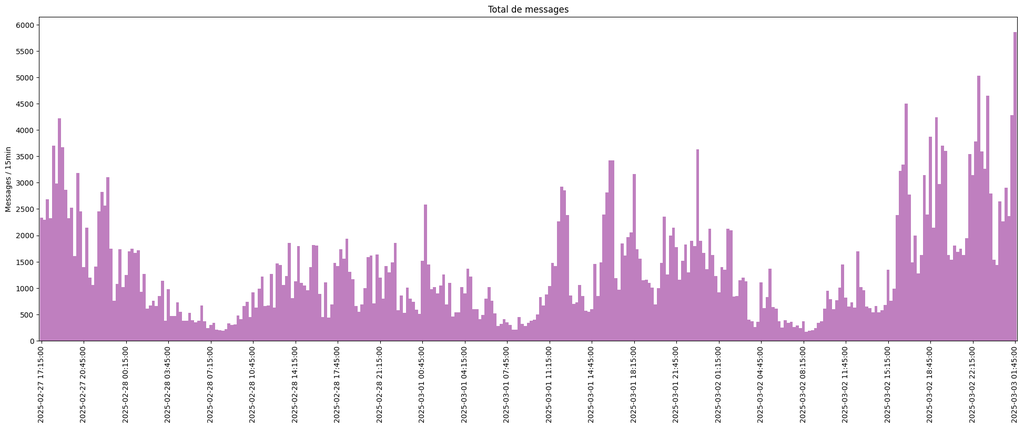

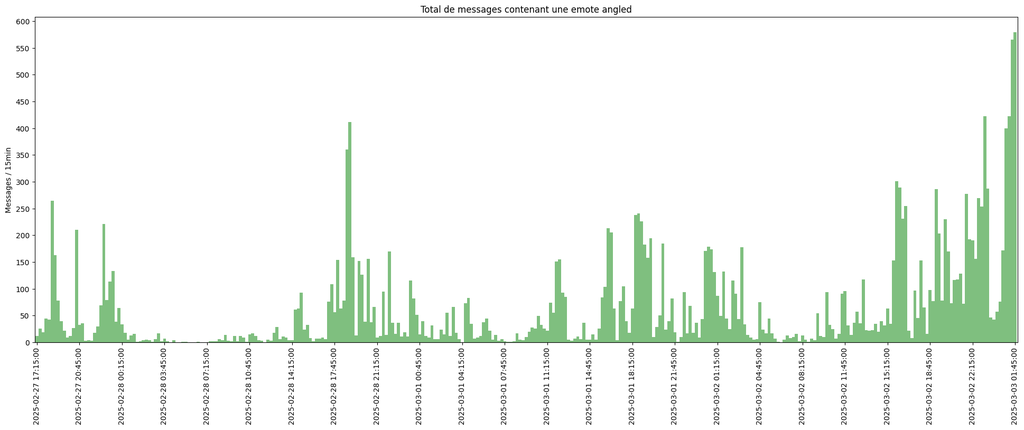

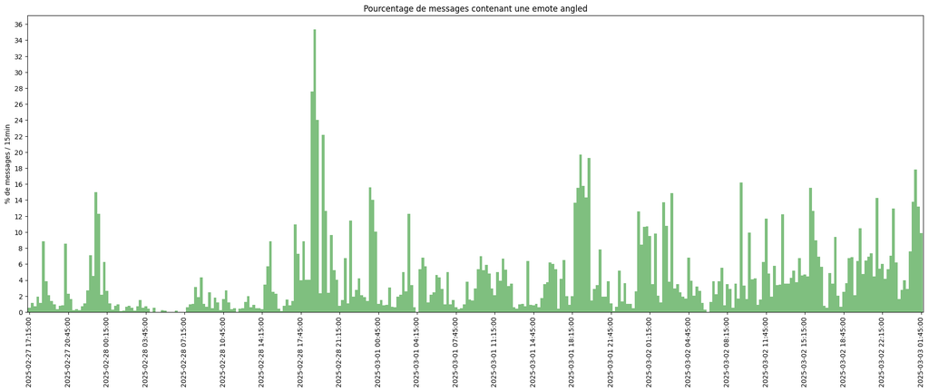

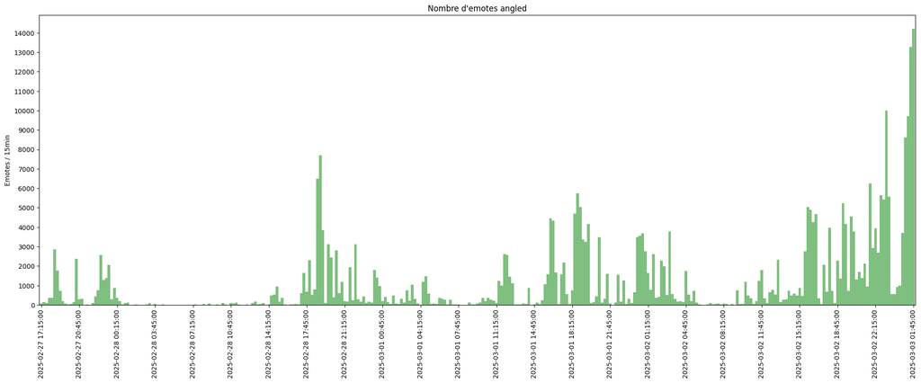

## Impact des culottes publiées par la pire communauté

Messages

433,908

'angledPanties' messages

7,250

'angledPanties' emotes

143,545

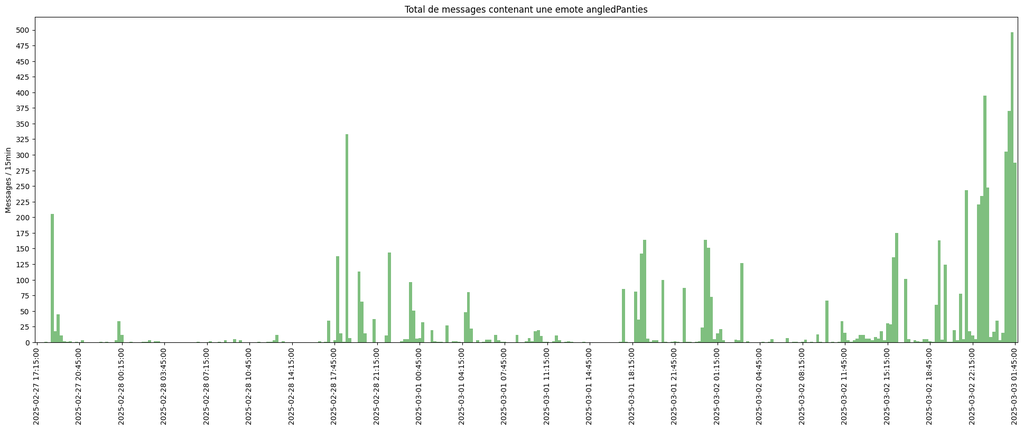

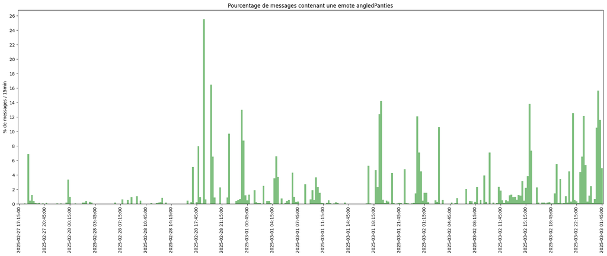

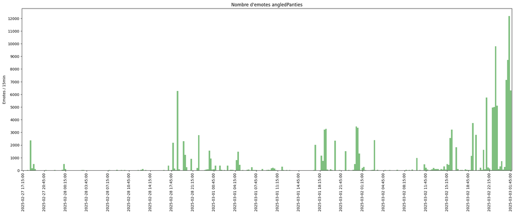

## Impact des autres emotes publiées par la pire communauté

Et les autres emotes de la chaine ?

angledDance

20,025

angledVroom

31,572

angledPet

3,079

angledBounce

16,651

angledJam

11,301

angledPanic

1,710

angledPanties

143,545

angledLove

40,108

angledGG

14,784

angledGun

8,659

angledBonk

716

angledCry

2,400

angledVieux

2,891

angledBlush

2,602

angledSip

78

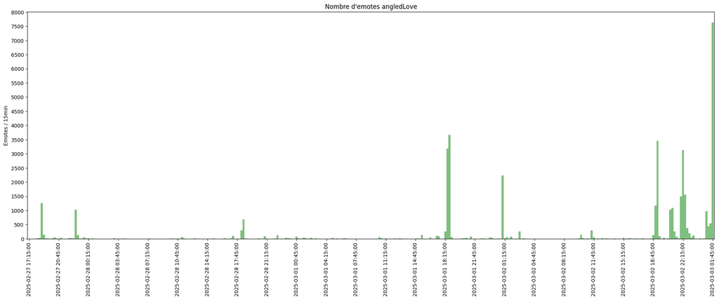

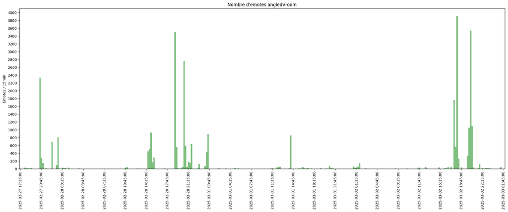

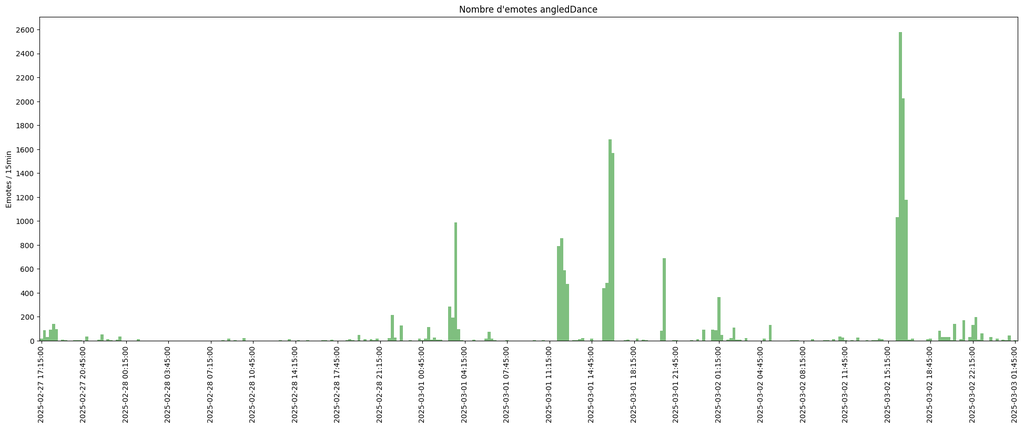

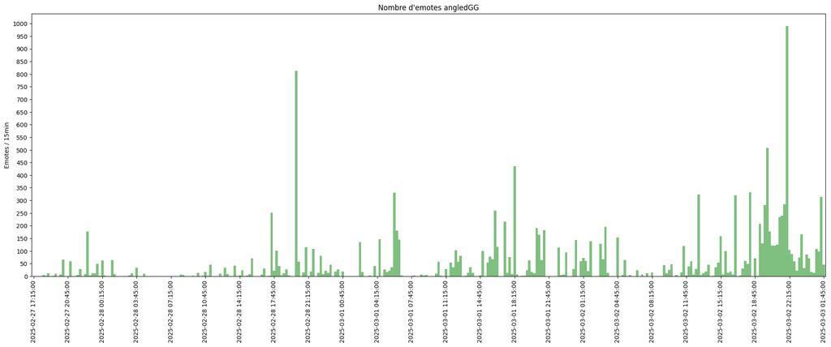

## Et les autres communautés ?

Quelle communauté a eu le plus d'impact ?

Messages Angle Droit

20,257

Emotes Angle Droit

349,568

Messages Gomart

11,244

Emotes Gomart

90,803

Messages Antoine Daniel

3,893

Emotes Antoine Daniel

23,265

Messages Zerator

2,814

Emotes Zerator

12,256

## Leaderboard

Qui a le plus posté ? Qui a mené les troupes ?

### AngledPanties

Viewers

320

Messages Top 10

2,695

Messages Top 50

5,575

Messages Top 100

6,540

Messages

7,244

| viewer | position | messages |
| --- | --- | --- |
| Brioche_CS | 1 | 503 |
| kanYo__ | 2 | 373 |
| Kanasucr | 3 | 361 |
| ptitepolyne | 4 | 302 |
| starlight_clownsprince | 5 | 250 |
| ShealdZ | 6 | 220 |
| Alzenith_ | 7 | 189 |
| Soladev | 8 | 178 |
| lucator91 | 9 | 177 |
| BloodyKanary | 10 | 142 |

[figure not shown]

### All emotes

Viewers

479

Messages Top 10

7,038

Messages Top 50

14,555

Messages Top 100

17,724

Messages

20,193

| viewer | position | messages |
| --- | --- | --- |
| Brioche_CS | 1 | 996 |
| Kanasucr | 2 | 941 |
| ptitepolyne | 3 | 917 |
| Alzenith_ | 4 | 872 |
| ShealdZ | 5 | 798 |
| kanYo__ | 6 | 669 |
| sam_fumi | 7 | 570 |
| BillySalsa_ | 8 | 458 |
| BloodyKanary | 9 | 417 |
| lucator91 | 10 | 400 |

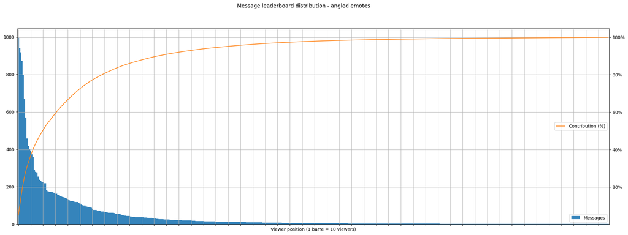

## Conclusion

La pire commu est une bande de petites guivaumes rigolotes dégénérés.